# 時系列分析 第 12 回

GARCH モデル

Kenichiro Tamaki

2022 年 6 月 27 日

# 1 パッケージ

必要なパッケージは次である.

```r
library(readxl) # xls ファイルの読込
library(quantmod) # 時系列データに変換
```

# 7 GARCH モデル

## はじめに

- ファイナンス分野では, 標準偏差のことを ボラティリティ という
- リスク資産の評価や金融商品の価格評価などで, ボラティリティは極めて重要な役割を果たす
- 株価などの金融時系列データでは, 収益率に相関はほぼないが, 大きく変動する時期が集中して現れる傾向がある
  - 収益率には相関がない (効率的市場仮説)
  - 収益率の変動には相関がある (ボラティリティ・クラスタリング)
- ARMAなどの時系列モデルによる分析は困難である
  - ボラティリティ変動モデル (GARCH モデル, SV モデル)

## 7.1 ボラティリティのモデル化の重要性

**効率的市場仮説**

- 株価は利用可能な情報を反映して適切に決定されている
- 株式市場が効率的に機能しているので, 株価の予測は不可能である
- 株式収益率 $y_{t}$ のモデル化を考える
- 効率的市場仮説では, 将来の株価の変動は過去の株価の変動とは無関係である

$$y_{t} = \mu + u_{t}, \quad u_{t} \sim \text{WN} (\sigma^{2})$$

**株式収益率の特徴 (図 7.1, p.148)**

- データ：日本, イギリス, アメリカの MSCI 指数の日次株式収益率
  - (a), (c), (e): 株式収益率のコレログラム  
    自己相関はほぼない
  - (b), (d), (f): 株式収益率の 2 乗 のコレログラム  
    自己相関が長期にわたって存在する
- 金融データの変化率には自己相関は無いが, 2 乗系列には自己相関がある傾向がある
- ARMA モデルは原系列に自己相関がある
  - 金融データの自己相関構造を分析するには別のモデルが必要である

**例**

MSCI が提供している株式指数を用いる.

- https://www.msci.com/

上記の「Solutions」→「Indexes」→「PERFORMANCE 」→「End of Day Index Data Search」から, 様々なデータ (xls ファイル) をダウンロードできる.

ここでは, 次のデータを用いる.

- 2012 年 1 月から 2015 年 12 月までの 4 年間の日次株式指数
- 日本, イギリス, アメリカの 3 カ国

ファイル名をそれぞれ「JP.xls」,「UK.xls」, 「US.xls」とする. 必要ない箇所を削除し, さらに, 文字列形式であるから Excel か R で変換する必要がある. ファイルは, 1列目は日付, 2列目は数値に変換済とする.

RStudio の右上にある「Environment」→「Import Dateset」→「From Excel..」において, xls ファイルの読込が出来る. または, 次を実行する.

```r
JP <- read_excel("JP.xls") # 日本
UK <- read_excel("UK.xls") # イギリス
US <- read_excel("US.xls") # アメリカ
```

時系列に変換する.

```r
JP <- as.xts(read.zoo(JP)) # 日本
UK <- as.xts(read.zoo(UK)) # イギリス
US <- as.xts(read.zoo(US)) # アメリカ
MSCI <- cbind(JP, UK, US) # データを結合
```

対数収益率 ($\%$) に変換する.

```r
JP.r <- dailyReturn(MSCI$JP, type = 'log') * 100 # 日本
UK.r <- dailyReturn(MSCI$UK, type = 'log') * 100 # イギリス
US.r <- dailyReturn(MSCI$US, type = 'log') * 100 # アメリカ
MSCI.r <- cbind(JP.r, UK.r, US.r) # データを結合
names(MSCI.r) <- names(MSCI) # 名称を変更
```

株式指数, 対数収益率, 対数収益率の 2 乗について, 時系列とコレログラムをプロットする.

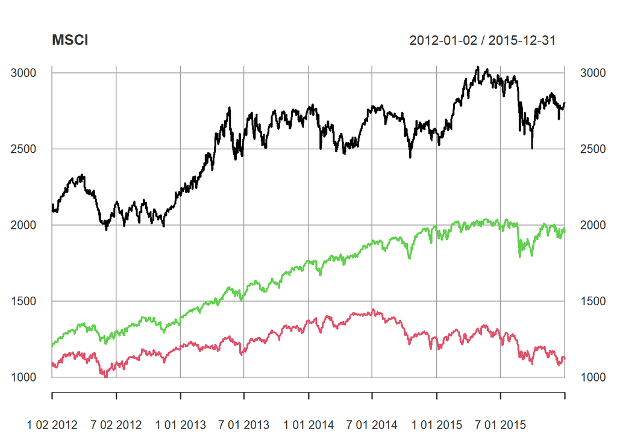

```r
plot(MSCI) # 株式指数の時系列プロット
```

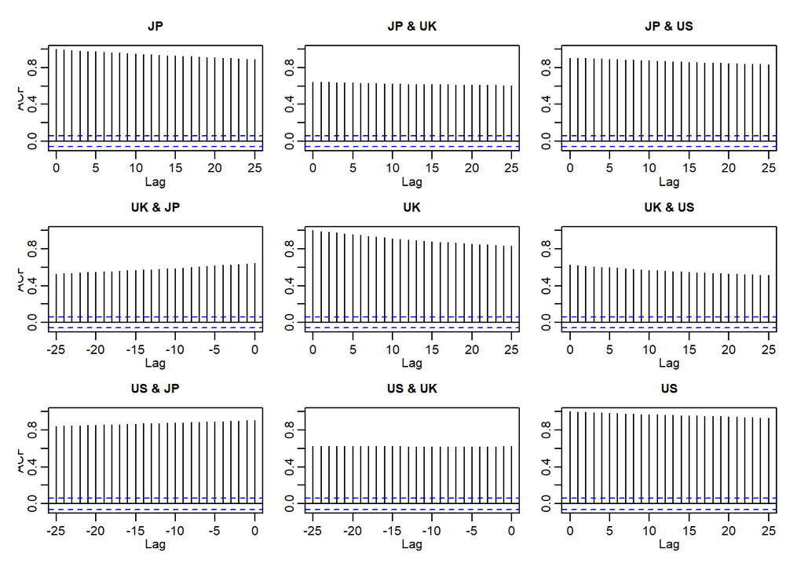

```r
acf(coredata(MSCI)) # 株式指数のコレログラム
```

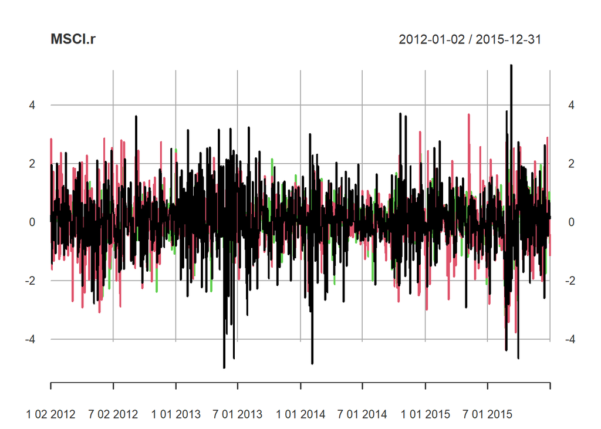

```r
plot(MSCI.r) # 対数収益率の時系列プロット
```

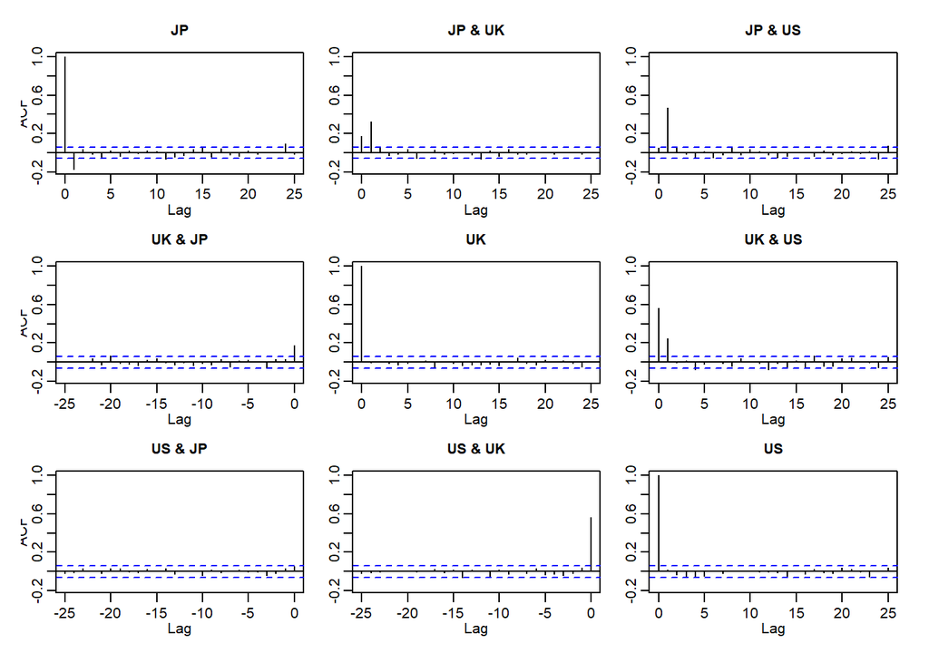

```r
acf(coredata(MSCI.r)) # 対数収益率のコレログラム
```

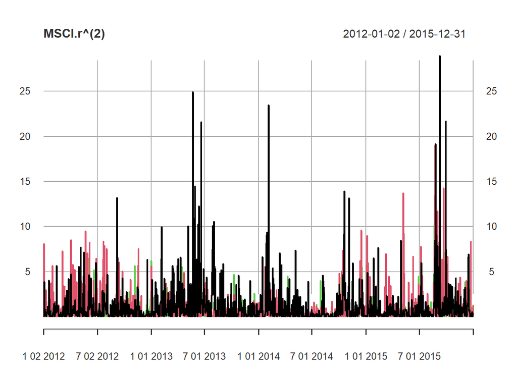

```r
plot(MSCI.r^(2)) # 対数収益率の 2 乗の時系列プロット
```

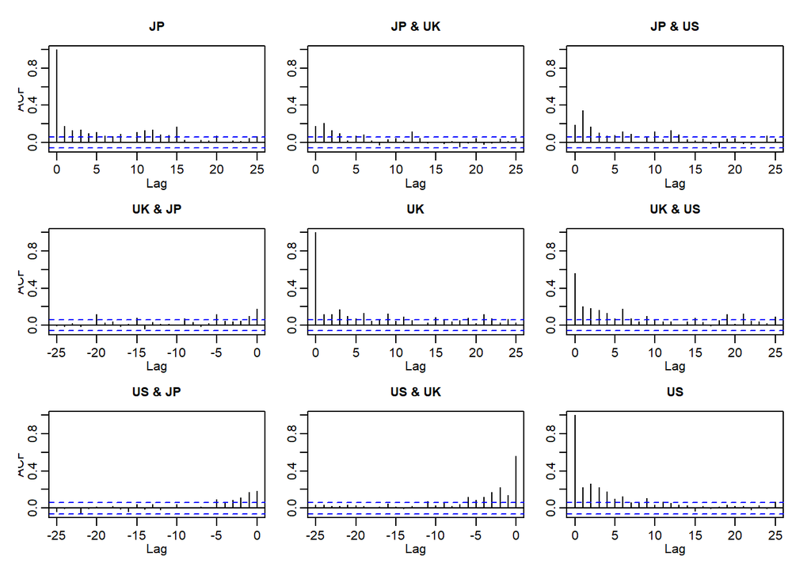

```r
acf(coredata(MSCI.r)^(2)) # 対数収益率の 2 乗のコレログラム
```

ARMA モデルの場合は次である.

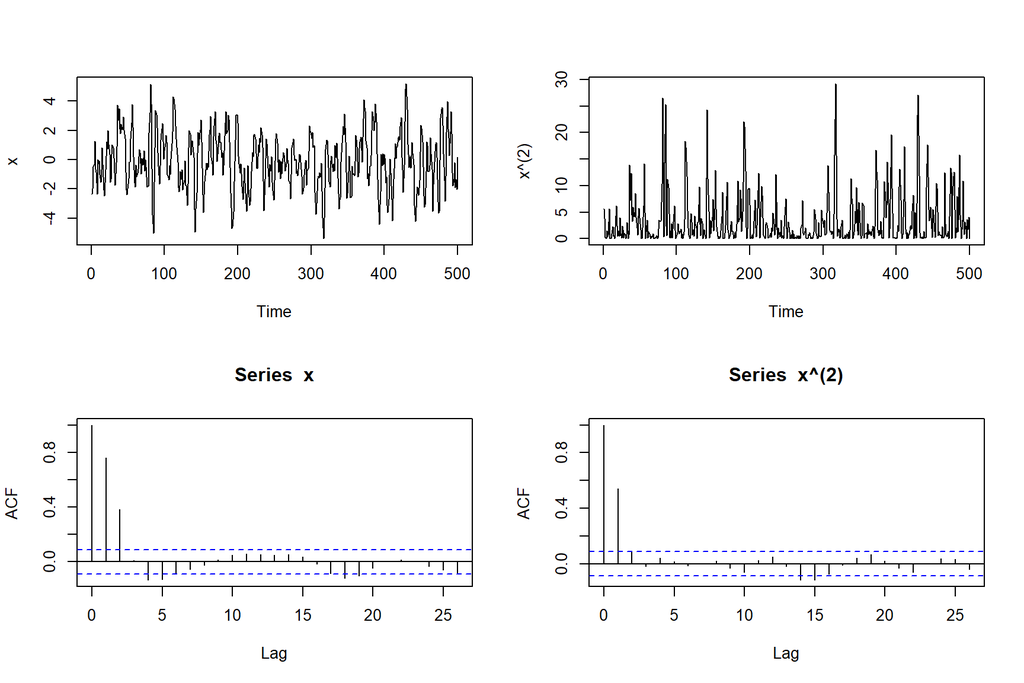

```r
x <- arima.sim(n = 500, # 標本数
               list(ar = c(0.8, -0.4), # AR 係数
                    ma = c(0.3, 0.6))) # MA 係数
par(mfrow = c(2, 2)) # 画面を 2 × 2 に分割
plot(x) # 時系列プロット
plot(x^(2)) # 2 乗の時系列プロット
acf(x) # コレログラム
acf(x^(2)) #2 乗のコレログラム
```

**条件付分散のモデル化**

2 乗系列の自己相関をモデル化するために, 条件付分散を考える.

$$y_{t} = \mu_{t} + u_{t} = \mu_{t} + \sqrt{h_{t}} v_{t}, \quad v_{t} \sim
\text{iid} (0,1)$$

- $h_{t} = E[u_{t}^{2} \vert u_{t-1}, u_{t-2}, \dots]$: $u_{t}$ の条件付分散
- $y_{t}$ の条件付分布: $y_{t} \vert \Omega_{t-1} \sim (\mu_{t}, h_{t})$
- $\Omega_{t} = \{ y_{t}, y_{t-1}, \dots \}$: $t$ 時点で得られる情報の集合
- 条件付期待値 $\mu_{t}$ のモデル: AR, ARMAモデルなど
- 条件付分散 $h_{t}$ のモデル:
  - $h_{t}$ は確定的 $\Rightarrow$ 自己回帰分散不均一 (ARCH, Autoregressive Conditional Heteroskedasticity) モデル
  - $h_{t}$ は確率的 $\Rightarrow$ 確率的ボラティリティ(SV, Stochastic Volatility) モデル

## 7.2 GARCH モデル

### 7.2.1 ARCH モデル (Engle, 1982)

- ARCH$(1)$ モデル
  $$h_{t} = \omega + \alpha_{1} u_{t-1}^{2}$$
- ARCH$(m)$ モデル
  $$h_{t} = \omega + \alpha_{1} u_{t-1}^{2} + \dots + \alpha_{m} u_{t-m}^{2}$$
  - パラメータ制約: $h_{t} > 0$ より $\omega > 0$, $\alpha_{i} \ge 0$
  - $w_{t} = u_{t}^{2} - h_{t}$ とすると
    $$u_{t}^{2} = \omega + \alpha_{1} u_{t-1}^{2} + \dots + \alpha_{m}
    u_{t-m}^{2} + w_{t}$$
    であるから, $u_{t}^{2}$ は AR($m$) 過程に従う
  - $\mu_{t} = \mu$ のとき, $y_{t}$ は無相関である
    $$\text{Cov}[y_{t}, y_{t+k} \vert \Omega_{t-1}] = E[\sqrt{h_{t}} v_{t}
    \sqrt{h_{t+k}} v_{t+k} \vert \Omega_{t-1}] = E[\sqrt{h_{t}} v_{t}
    \sqrt{h_{t+k}} \vert \Omega_{t-1}] E[v_{t+k}] = 0$$

**ARCH$(m)$ モデルの定常性**

- 定常条件: $u_{t}^{2}$ の AR 特性方程式 $1 - \alpha_{1} z - \dots - \alpha_{m} z^{m} = 0$ の全ての解の絶対値が $1$ より大きい
  $\alpha_{i} \ge 0$ より
  $$\alpha_{1} + \dots + \alpha_{m} < 1$$
- $u_{t}$ の (無条件) 分散は
  $$E[u_{t}^{2}] = \frac{\omega}{1 - \alpha_{1} - \dots - \alpha_{m}}$$
- ARCH$(1)$ における $u_{t}$ の 4 次モーメントは
  $$E[u_{t}^{4}] = \frac{\omega}{1 - 3\alpha_{1}^{2}}$$
  であるから, 4 次モーメントの存在条件は, $\alpha_{1}^{2} < 1/3$

### 7.2.2 GARCHモデル (Bollerslev, 1986)

- Generalized ARCH model
- 金融データの 2 乗系列は長期にわたって正の自己相関をもつことが多い  
  $\Rightarrow$ ARCHモデルでは次数が大きくなり過ぎる
- GARCH$(r, m)$ モデル
  $$h_{t} = \omega + \beta_{1} h_{t-1} + \dots + \beta_{r} h_{t-r} +
  \alpha_{1} u_{t-1}^{2} + \dots + \alpha_{m} u_{t-m}^{2}$$
  - パラメータ制約: $h_{t} > 0$ より $\omega > 0$, $\alpha_{i} \ge 0$, $\beta_{j} \ge 0$
  - $w_{t} = u_{t}^{2} - h_{t}$ とすると
    $$u_{t}^{2} = \omega + (\alpha_{1} + \beta_{1}) u_{t-1}^{2} + \dots +
    (\alpha_{p} + \beta_{p}) u_{t-p}^{2} + w_{t} - \beta_{1} w_{t-1} - \dots
    - \beta_{r} w_{t-r}$$
    であるから, $u_{t}^{2}$ は ARMA($p,r$) 過程に従う $(p = \max(r, m))$
  - $\mu_{t} = \mu$ のとき, $y_{t}$ は無相関である

**GARCH$(1,1)$ モデルの定常性**

- 定常条件: $u_{t}^{2}$ の AR 特性方程式 $1 - (\alpha_{1} + \beta_{1}) z = 0$ の解の絶対値が $1$ より大きい
  $\alpha_{1}, \beta_{1} \ge 0$ より
  $$\alpha_{1} + \beta_{1} < 1$$
- $u_{t}$ の (無条件) 分散は
  $$E[u_{t}^{2}] = \frac{\omega}{1 - \alpha_{1} - \beta_{1}}$$

#### 1.0.0.1 GARCHタイプモデル

- IGARCH(1,1) (Integrated GARCH)
  $$h_{t} = \omega + \beta_{1} h_{t-1} + \alpha_{1} u_{t-1}^{2}, \quad
  \alpha_{1} + \beta_{1} = 1$$
  - 定常性を満たさない
  - 恒久的な持続性をもつ
- GJR(1,1) (Glosten-Jagannathan-Runkle)
  $$h_{t} = \omega + \beta_{1} h_{t-1} + \alpha_{1} u_{t-1}^{2} + \gamma
  u_{t-1}^{2} I_{t-1}, \quad
  I_{t-1} =
  \begin{cases}
  1, & u_{t-1} < 0 \\
  0, & u_{t-1} \ge 0 \\
  \end{cases}$$
  - 非対称性もつ
  - $\gamma > 0$ $\Rightarrow$ 正と負のショックでは, 負のショックがより大きな影響をもつ (レバレッジ効果)
- EGARCH(1,1) (Exponential GARCH)
  $$\log h_{t} = \omega + \beta_{1} \log h_{t-1} + \gamma v_{t-1} + \delta
  \left( \lvert v_{t-1} \rvert - E[\lvert v_{t-1} \rvert] \right)$$
  - 非対称性をもつ
  - パラメータ制約は必要ない
- GARCH(1,1)-M (GARCH-in-Mean)
  $$y_{t} = \mu_{t} + \delta h_{t} + u_{t}$$
  - $\delta > 0$ $\Rightarrow$ 条件付分散が高いとき, 条件付期待値も高くなる (ハイリスク・ハイリターン)
  - 条件付分散が条件付期待値に影響を与える

## 7.3 GARCH モデルの統計的推測

### 7.3.1 GARCH モデルの推定

- 条件付最尤法を用いてパラメータを推定
- $v_{t}$ の分布として正規分布を用いるが, 他にも次の分布が用いられる
  - $t$ 分布 $\Rightarrow$ 正規分布より裾が厚い
  - Skewed $t$ 分布 $\Rightarrow$ 非対称性をもつ $t$ 分布
  - 一般化誤差分布 (GED, Generalized Error Distribution)

### 7.3.2 GARCH モデルの選択と診断

- モデル選択
  - 情報量基準 (AIC, BIC など) を用いる
  - 包含関係のあるモデル間で比較するときに用いることができる
  - 包含関係がないモデル間で比較しても意味はない
    - GARCH と GJR は包含関係がある (GJR において $\gamma = 0$ とすると GARCH になる)
    - GARCH と EGARCH に包含関係はない
    - ARMA と GARCH に包含関係はない
- モデル診断
  - GARCH は 2 乗系列の自己相関をモデル化する
  - $v_{t}$ だけではなく, $v_{t}^{2}$ の自己相関について検定する